# Chiara homework week 6 day 3

```r
library(tidyverse)
library(infer)
library(janitor)
```

# 1 MPV

## Task 1:

Load the data again, clean_names(), and re-familiarise yourself with it

```r
ames <- clean_names(read_csv("data/ames.csv"))
```

```r
dim(ames)
```

```
[1] 2930   82
```

```r
names(ames)
```

```
 [1] "order"           "pid"             "ms_sub_class"    "ms_zoning"       "lot_frontage"    "lot_area"        "street"
 [8] "alley"           "lot_shape"       "land_contour"    "utilities"       "lot_config"      "land_slope"      "neighborhood"
[15] "condition_1"     "condition_2"     "bldg_type"       "house_style"     "overall_qual"    "overall_cond"    "year_built"
[22] "year_remod_add"  "roof_style"      "roof_matl"       "exterior_1st"    "exterior_2nd"    "mas_vnr_type"    "mas_vnr_area"
[29] "exter_qual"      "exter_cond"      "foundation"      "bsmt_qual"       "bsmt_cond"       "bsmt_exposure"   "bsmt_fin_type_1"
[36] "bsmt_fin_sf_1"   "bsmt_fin_type_2" "bsmt_fin_sf_2"   "bsmt_unf_sf"     "total_bsmt_sf"   "heating"         "heating_qc"
[43] "central_air"     "electrical"      "x1st_flr_sf"     "x2nd_flr_sf"     "low_qual_fin_sf" "gr_liv_area"     "bsmt_full_bath"
[50] "bsmt_half_bath"  "full_bath"       "half_bath"       "bedroom_abv_gr"  "kitchen_abv_gr"  "kitchen_qual"    "tot_rms_abv_grd"
[57] "functional"      "fireplaces"      "fireplace_qu"    "garage_type"     "garage_yr_blt"   "garage_finish"   "garage_cars"
[64] "garage_area"     "garage_qual"     "garage_cond"     "paved_drive"     "wood_deck_sf"    "open_porch_sf"   "enclosed_porch"
[71] "x3ssn_porch"     "screen_porch"    "pool_area"       "pool_qc"         "fence"           "misc_feature"    "misc_val"
[78] "mo_sold"         "yr_sold"         "sale_type"       "sale_condition"  "sale_price"
```

## Task 2:

Investigate the distribution of lot_area. Is the distribution roughly normal? If not, what problems do you find?

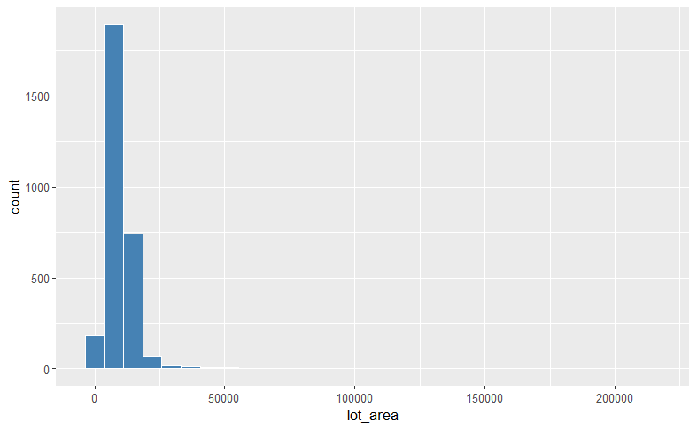

```r
ames %>%
  ggplot() +
  aes(x = lot_area) +
  geom_histogram(col = "white",
                 fill = "steelblue")
```

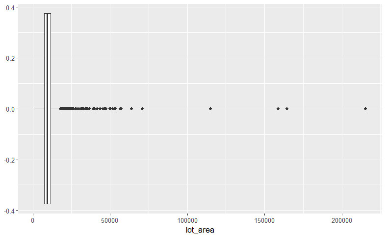

```r
ames %>%
  ggplot() +
  aes(x = lot_area) +
  geom_boxplot()
```

Having a first sight both of the histogram and of the boxplot, it seems that the distribution of lot_area is ruoghly right skewed

## Task 3:

Compute and visualise a bootstrap sampling distribution for the mean(lot_area) of the sold houses.

```r
bootstrap_resample_ames <- ames %>%
  specify(response = lot_area) %>% #specify the variable of interest
  generate(reps = 5000, type = "bootstrap") %>% #generate the replicate resamples
  calculate(stat = "mean") # calculate the statistic of interest for each resample


bootstrap_resample_ames
```

```
Response: lot_area (numeric)
```

| replicate | stat |
| --- | --- |
| 1 | 10167.159 |
| 2 | 9948.571 |
| 3 | 10512.045 |
| 4 | 10152.537 |
| 5 | 10074.069 |
| 6 | 10356.975 |
| 7 | 10256.456 |
| 8 | 10092.065 |
| 9 | 10010.738 |
| 10 | 10118.754 |

[output cut: 990 more lines]

I’ve created a bootstrap sampling distribution for the mean of lot_area.

Now I am going to visualise it.

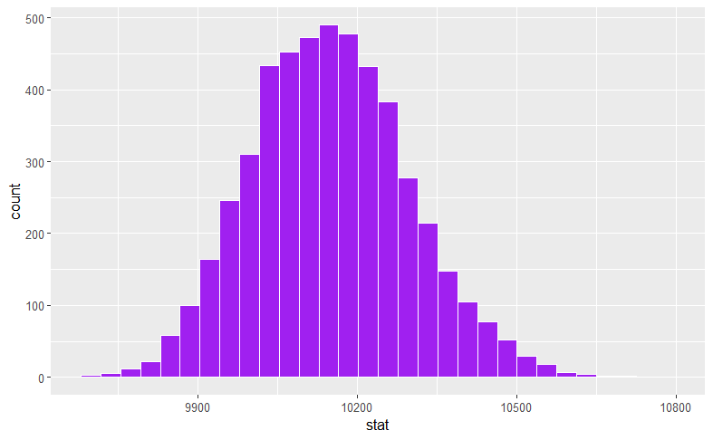

```r
bootstrap_resample_ames %>%
  ggplot() +
  aes(x = stat) +
  geom_histogram(colour = "white",
                 fill = "purple")
```

As we expected, the distribution seems very similar to the normal distribution!

## Task 4:

Use your bootstrap distribution to calculate a 95% CI for mean(lot_area), and visualise it on the distribution

```r
infer_ci_95 <- bootstrap_resample_ames %>%
  get_ci(level = 0.95, type = "percentile")
#level adjust CI, type adjust type of CI
infer_ci_95
```

| lower_ci | upper_ci |
| --- | --- |
| 9875.209 | 10455.23 |

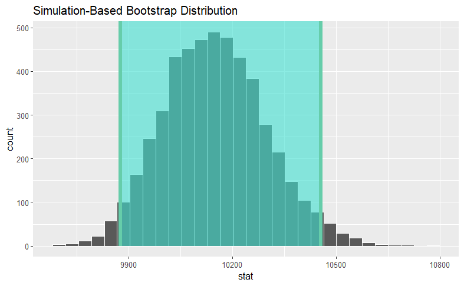

```r
bootstrap_resample_ames %>%
  visualise(bins = 30) +
  shade_ci(endpoints = infer_ci_95)
```

```r
mean_bootstrap <- bootstrap_resample_ames %>%
  summarise(mean = mean(stat))

mean_bootstrap
```

| mean |
| --- |
| 10148.63 |

```r
mean_95 <- bootstrap_resample_ames %>%
  filter(stat >= 9875 & stat <= 10451) %>%
  summarise(mean = mean(stat))

mean_95
```

| mean |
| --- |
| 10146.69 |

## Task 5:

You would like to know the mean(lot_area) of the sold houses with higher confidence. Calculate the 99% CI for this variable (you can re-use your bootstrap distribution from above). Is it narrower or broader than the 95% CI? Does that make sense?

```r
infer_ci_99 <- bootstrap_resample_ames %>%
  get_ci(level = 0.99, type = "percentile")
#level adjust CI, type adjust type of CI
infer_ci_99
```

| lower_ci | upper_ci |
| --- | --- |
| 9798.065 | 10552.61 |

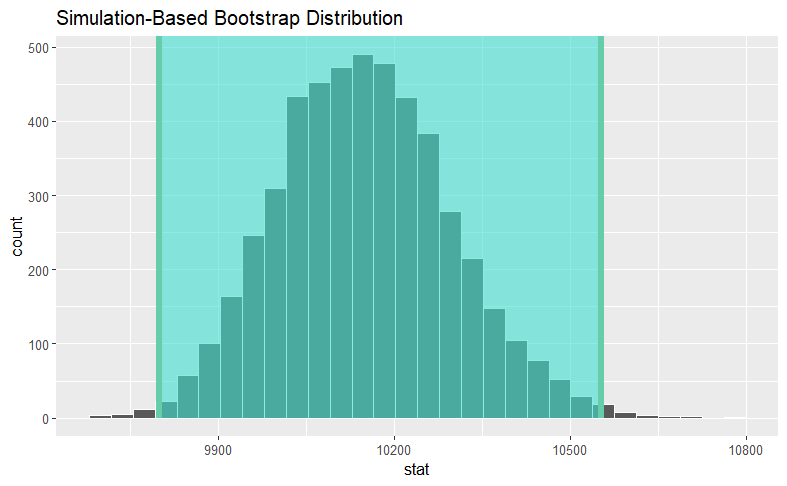

```r
bootstrap_resample_ames %>%
  visualise(bins = 30) +
  shade_ci(endpoints = infer_ci_99)
```

```r
mean_99 <- bootstrap_resample_ames %>%
  filter(stat >= 9810 & stat <= 10548) %>%
  summarise(mean = mean(stat))

mean_99
```

| mean |
| --- |
| 10148.44 |

Using the 99% CI we obtain an roughly higher value for the mean of lot_area!

## Task 6:

Calculate the point estimate of the mean(lot_area)

```r
mean_bootstrap <- bootstrap_resample_ames %>%
  summarise(mean = mean(stat))

mean_bootstrap
```

| mean |
| --- |
| 10148.63 |

# Extension

## Task 1:

Calculate a point estimate and 95% CI for the proportion of houses in the data built before 1920. Does the number of reps you use matter? [Investigate reps from 200 up to 50000, memory of your laptop permitting].

```r
ames_1920 <- ames %>%
  filter(yr_sold <= 1920)
```

```r
#200 reps

ames_1920_resample_200 <- ames_1920 %>%
  specify(response = lot_area) %>%
  generate(reps = 200, type = "bootstrap") %>%
  calculate(stat = "mean")
```

```
Error in t.test.default(response_variable(x)) :
  non ci sono abbstanza osservazioni in 'x'
```

## Correction:

```r
ames_before_1920 <- ames %>%
  mutate(before_1920 = as.numeric(year_built < 1920))
```

```r
bootstrap_distn_200 <- ames_before_1920 %>%
  specify(response = before_1920) %>%
  generate(reps = 200, type = "bootstrap") %>%
  calculate(stat = "mean")

bootstrap_distn_1000 <- ames_before_1920 %>%
  specify(response = before_1920) %>%
  generate(reps = 1000, type = "bootstrap") %>%
  calculate(stat = "mean")

bootstrap_distn_10000 <- ames_before_1920 %>%
  specify(response = before_1920) %>%
  generate(reps = 10000, type = "bootstrap") %>%
  calculate(stat = "mean")

bootstrap_distn_30000 <- ames_before_1920 %>%
  specify(response = before_1920) %>%
  generate(reps = 30000, type = "bootstrap") %>%
  calculate(stat = "mean")

bootstrap_distn_50000 <- ames_before_1920 %>%
  specify(response = before_1920) %>%
  generate(reps = 50000, type = "bootstrap") %>%
  calculate(stat = "mean")
```

```r
point_est <- ames_before_1920 %>%
  summarise(point_est = mean(before_1920))
point_est
```

| point_est |
| --- |
| 0.06006826 |

```r
point_est <- bootstrap_distn_50000 %>%
  summarise(point_est = mean(stat))
point_est
```

| point_est |
| --- |
| 0.06008349 |

```r
before_1920_ci95_200 <- bootstrap_distn_200 %>%
  get_ci(level = 0.95, type = "percentile")
before_1920_ci95_200
```

| lower_ci | upper_ci |
| --- | --- |
| 0.05119454 | 0.0696587 |

```r
before_1920_ci95_1000 <- bootstrap_distn_1000 %>%
  get_ci(level = 0.95, type = "percentile")
before_1920_ci95_1000
```

| lower_ci | upper_ci |
| --- | --- |
| 0.0515273 | 0.06928328 |

```r
before_1920_ci95_10000 <- bootstrap_distn_10000 %>%
  get_ci(level = 0.95, type = "percentile")
before_1920_ci95_10000
```

| lower_ci | upper_ci |
| --- | --- |
| 0.05153584 | 0.06894198 |

```r
before_1920_ci95_30000 <- bootstrap_distn_30000 %>%
  get_ci(level = 0.95, type = "percentile")
before_1920_ci95_30000
```

| lower_ci | upper_ci |
| --- | --- |
| 0.05153584 | 0.06894198 |

```r
before_1920_ci95_50000 <- bootstrap_distn_50000 %>%
  get_ci(level = 0.95, type = "percentile")
before_1920_ci95_200
```

| lower_ci | upper_ci |
| --- | --- |
| 0.05119454 | 0.0696587 |

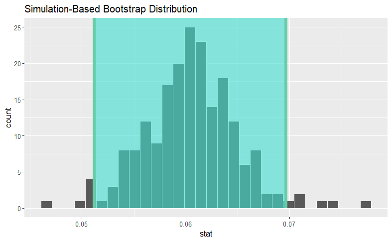

```r
bootstrap_distn_200 %>%
  visualise(bins = 30) +
  shade_ci(endpoints = before_1920_ci95_200)
```

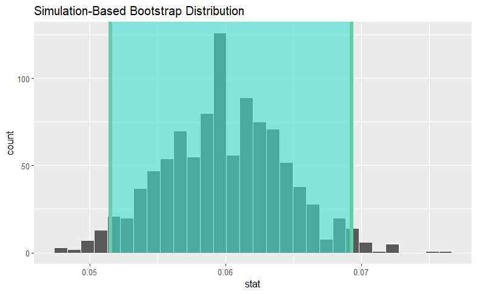

```r
bootstrap_distn_1000 %>%
  visualise(bins = 30) +
  shade_ci(endpoints = before_1920_ci95_1000)
```

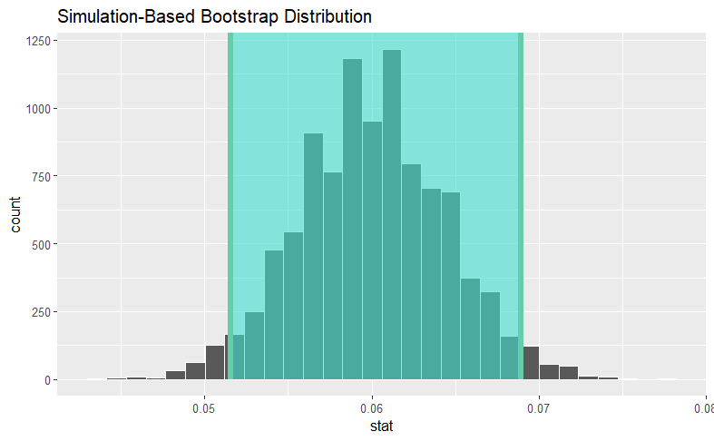

```r
bootstrap_distn_10000 %>%
  visualise(bins = 30) +
  shade_ci(endpoints = before_1920_ci95_10000)
```

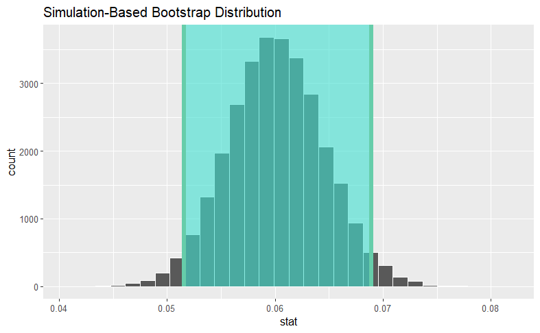

```r
bootstrap_distn_30000 %>%
  visualise(bins = 30) +
  shade_ci(endpoints = before_1920_ci95_30000)
```

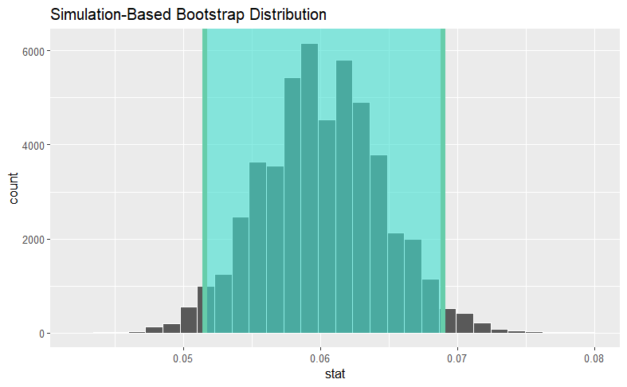

```r
bootstrap_distn_50000 %>%
  visualise(bins = 30) +
  shade_ci(endpoints = before_1920_ci95_50000)
```

## What is a CI?

The CI is a measure of how confident we are about our uncertainty.

95% is about, how many CI contain a parameter!

With 90% confidence we can fill happy about 90% of our CIs With 95% confidence we can fill happy about 95% of our CIs

95% is an happy convention - by choosing 95% we are basically saying that we are happy to accept being wrong 5% of the time.

trad-off between sample-size - variability in the data - size of the effect

Depends on the variability of the data.

i.e. if we work in a “noisy” field e.g. psychology, we might choose 90% because it is too hard to meet a higher threshold

- ie work in a “noisy” field eg psychology
- we might choose 90% because it is too hard to meet a higher threshold